# Ch3: Linear Regression

Lab

Kylie

06/04/2019

# 3.6.2 Simple Linear Regression

Using the `lm()` function to fit a simple linear regression model. The basic syntax is `lm(y ∼ x, data)`, where `y` is the response, `x` is the predictor, and `data` is the data set in which these two variables are kept.

```r
# Looking at the data briefly:
#fix(Boston) # or View(Boston)
names(Boston) # lists the variable names
```

```
##  [1] "crim"    "zn"      "indus"   "chas"    "nox"     "rm"      "age"
##  [8] "dis"     "rad"     "tax"     "ptratio" "black"   "lstat"   "medv"
```

```r
as_tibble(Boston) # alternative way to view a subsection of the data
```

```
## # A tibble: 506 x 14
##       crim    zn indus  chas   nox    rm   age   dis   rad   tax ptratio
##      <dbl> <dbl> <dbl> <int> <dbl> <dbl> <dbl> <dbl> <int> <dbl>   <dbl>
##  1 0.00632  18    2.31     0 0.538  6.58  65.2  4.09     1   296    15.3
##  2 0.0273    0    7.07     0 0.469  6.42  78.9  4.97     2   242    17.8
##  3 0.0273    0    7.07     0 0.469  7.18  61.1  4.97     2   242    17.8
##  4 0.0324    0    2.18     0 0.458  7.00  45.8  6.06     3   222    18.7
##  5 0.0690    0    2.18     0 0.458  7.15  54.2  6.06     3   222    18.7
##  6 0.0298    0    2.18     0 0.458  6.43  58.7  6.06     3   222    18.7
##  7 0.0883   12.5  7.87     0 0.524  6.01  66.6  5.56     5   311    15.2
##  8 0.145    12.5  7.87     0 0.524  6.17  96.1  5.95     5   311    15.2
##  9 0.211    12.5  7.87     0 0.524  5.63 100    6.08     5   311    15.2
## 10 0.170    12.5  7.87     0 0.524  6.00  85.9  6.59     5   311    15.2
## # ... with 496 more rows, and 3 more variables: black <dbl>, lstat <dbl>,
## #   medv <dbl>
```

```r
# using the lm() function to fit a simple linear regression lm()
# model, with medv as the response and lstat as the predictor:
lm_fit <- lm(medv∼lstat, data=Boston)

lm_fit # outputs some basic information about the model
```

```
##
## Call:
## lm(formula = medv ~ lstat, data = Boston)
##
## Coefficients:
## (Intercept)        lstat
##       34.55        -0.95
```

```r
summary(lm_fit) # outputs more detail including pvalues and standard errors for the coefficients, as well as the R2 statistic and F-statistic for the model.
```

```
##
## Call:
## lm(formula = medv ~ lstat, data = Boston)
##
## Residuals:
##     Min      1Q  Median      3Q     Max
## -15.168  -3.990  -1.318   2.034  24.500
##
## Coefficients:
##             Estimate Std. Error t value Pr(>|t|)
## (Intercept) 34.55384    0.56263   61.41   <2e-16 ***
## lstat       -0.95005    0.03873  -24.53   <2e-16 ***
## ---
## Signif. codes:  0 '***' 0.001 '**' 0.01 '*' 0.05 '.' 0.1 ' ' 1
##
## Residual standard error: 6.216 on 504 degrees of freedom
## Multiple R-squared:  0.5441, Adjusted R-squared:  0.5432
## F-statistic: 601.6 on 1 and 504 DF,  p-value: < 2.2e-16
```

```r
names(lm_fit) # shows what other pieces of information are stored in lm_fit.
```

```
##  [1] "coefficients"  "residuals"     "effects"       "rank"
##  [5] "fitted.values" "assign"        "qr"            "df.residual"
##  [9] "xlevels"       "call"          "terms"         "model"
```

```r
# Although we can extract these quantities by name—e.g. lm.fit$coefficients—it is safer to use the extractor functions like coef() to access them.
coef(lm_fit)
```

```
## (Intercept)       lstat
##  34.5538409  -0.9500494
```

```r
confint(lm_fit) # confidence interval for the coefficient estimates
```

```
##                 2.5 %     97.5 %
## (Intercept) 33.448457 35.6592247
## lstat       -1.026148 -0.8739505
```

```r
predict(lm_fit, data.frame(lstat = c(5, 10, 15)), interval = "confidence") # produces confidence intervals for the prediction of medv for a given value of lstat
```

```
##        fit      lwr      upr
## 1 29.80359 29.00741 30.59978
## 2 25.05335 24.47413 25.63256
## 3 20.30310 19.73159 20.87461
```

```r
predict(lm_fit, data.frame(lstat = c(5, 10, 15)), interval = "prediction") # produces prediction intervals for the prediction of medv for a given value of lstat
```

```
##        fit       lwr      upr
## 1 29.80359 17.565675 42.04151
## 2 25.05335 12.827626 37.27907
## 3 20.30310  8.077742 32.52846
```

The difference between confidence intervals and prediction intervals:

Even if we knew f(X) (i.e., even if we knew the true values for $\beta_0, \beta_1, . . . , \beta_p$) the response value cannot be predicted perfectly because of the random (irreducible) error $\epsilon$ in the model ($Y = f(X) + \epsilon$). How much will $Y$ vary from $\widehat{Y}$? We use **prediction intervals** to answer this question. Prediction intervals are always wider than confidence intervals, because they incorporate both the error in the estimate for $f(X)$ (the reducible error) and the uncertainty as to how much an individual point will differ from the population regression plane (the irreducible error).

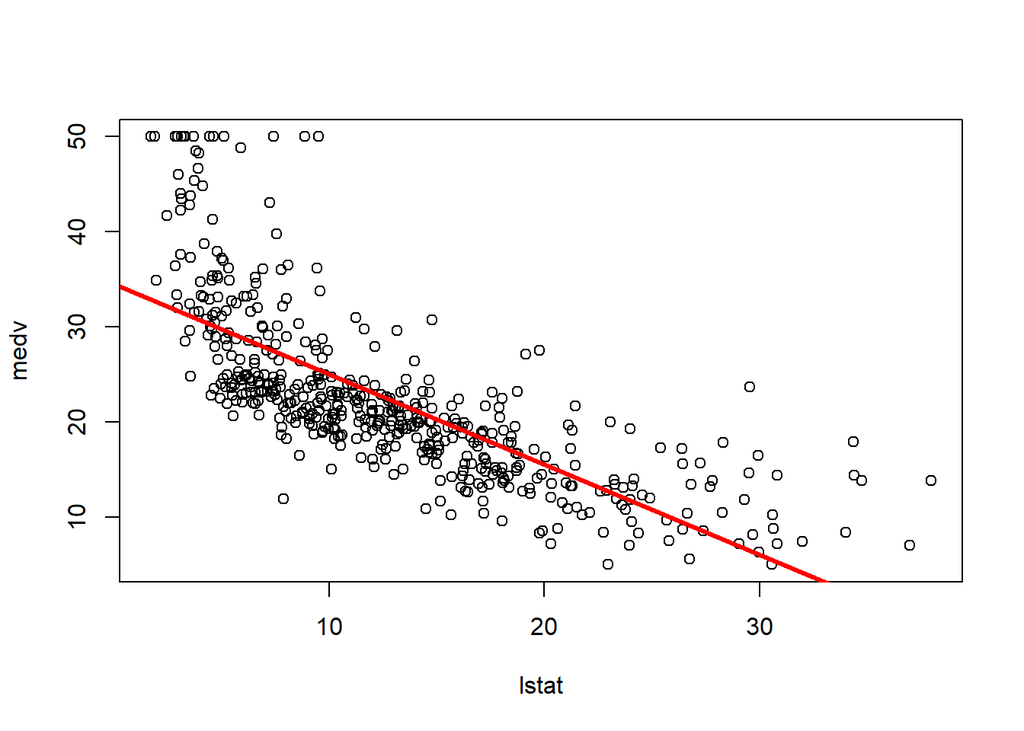

```r
# plotting data and fitted line
attach(Boston)
plot(lstat, medv)
abline (lm_fit)
# trying different linewidths, symbol shapes and colours
abline(lm_fit, lwd =3)
abline(lm_fit, lwd =3, col ="red")
```

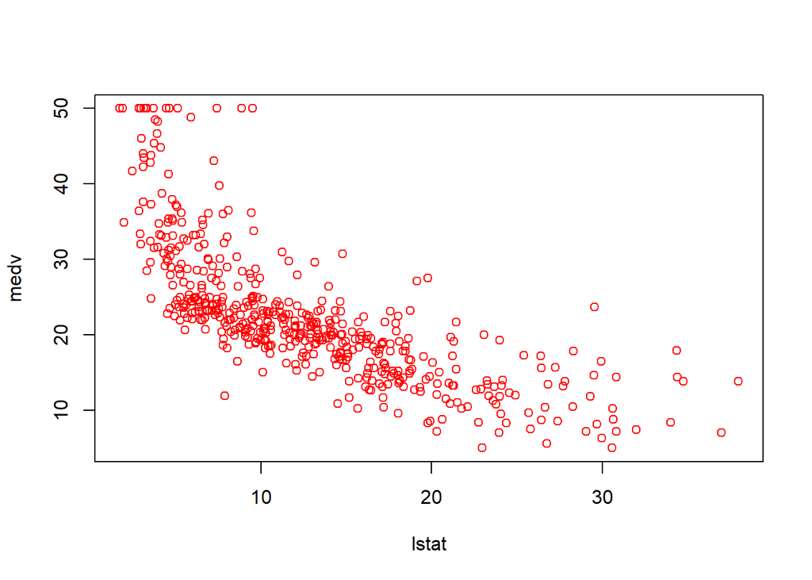

```r
plot(lstat, medv, col = "red")
```

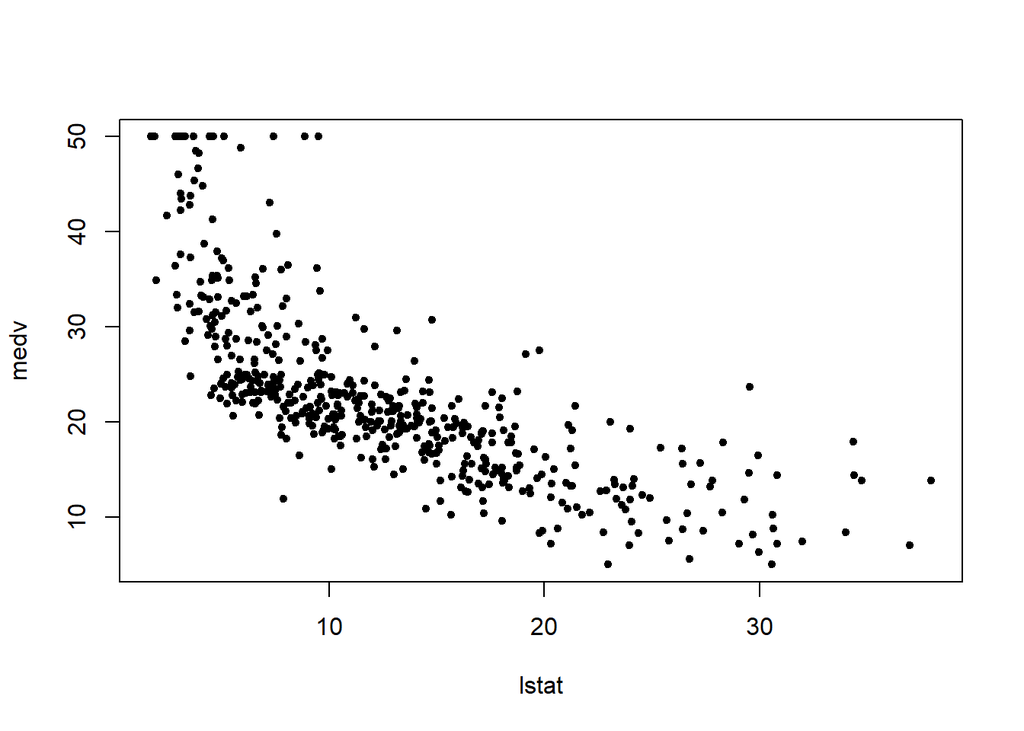

```r
plot(lstat, medv, pch =20)
```

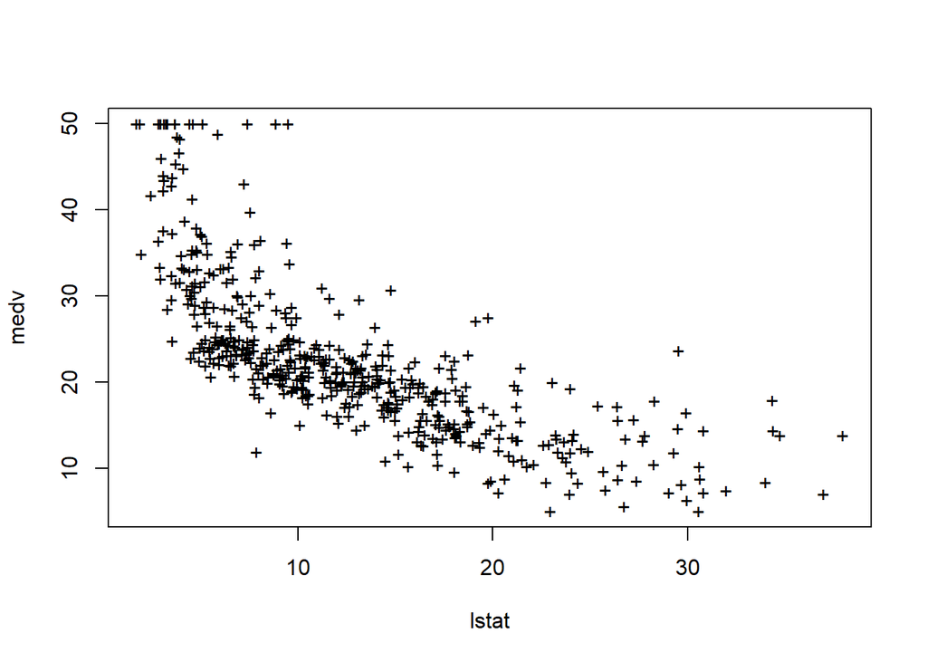

```r
plot(lstat, medv, pch = "+")
```

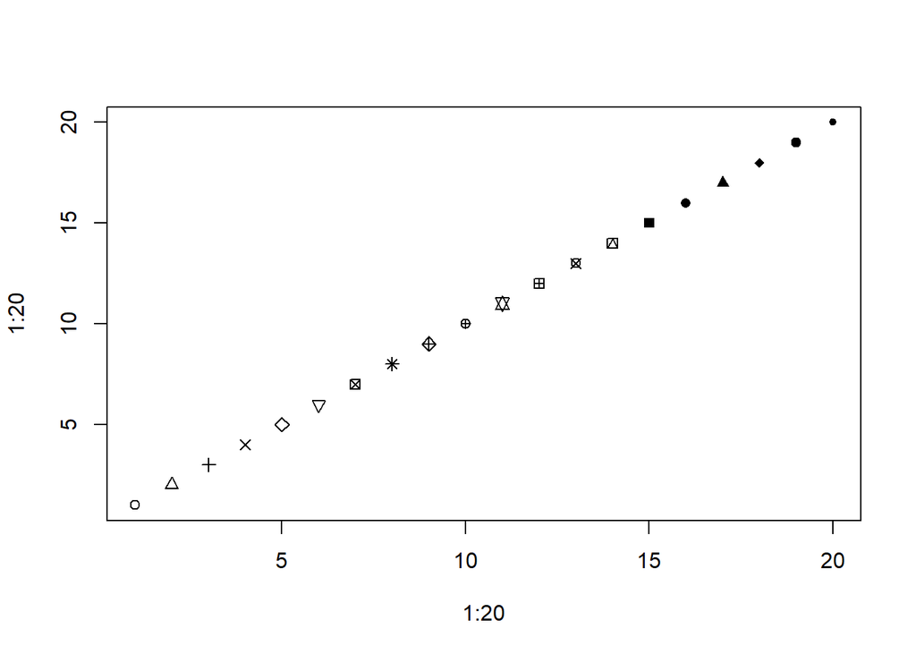

```r
plot (1:20, 1:20, pch =1:20)
```

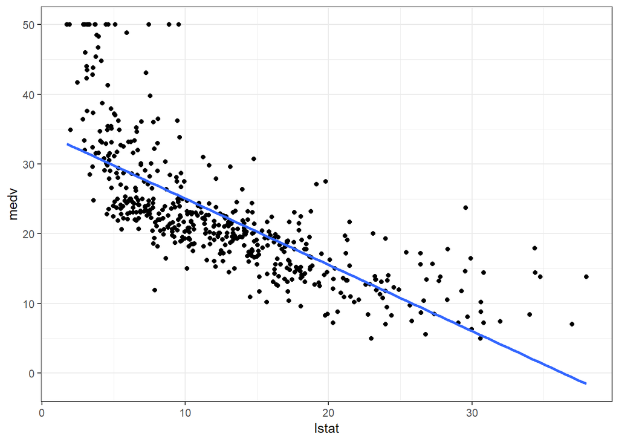

```r
# ggplot alternative:
theme_set(theme_bw()) # setting theme to black and white

ggplot(Boston, aes(x = lstat, y = medv)) +
  geom_point() +
  geom_smooth(method = "lm", se = FALSE)
```

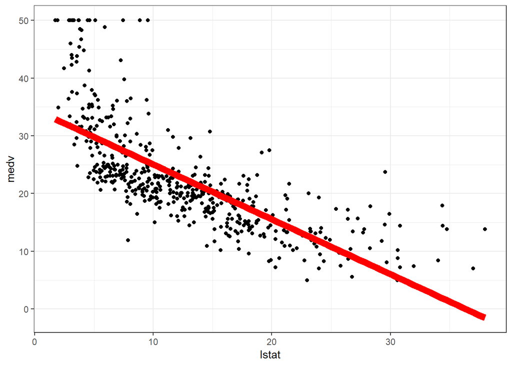

```r
# trying different linewidths, symbol shapes and colours
ggplot(Boston, aes(x = lstat, y = medv)) +
  geom_point() +
  geom_smooth(method = "lm", se = FALSE, lwd = 3, color = "red")
```

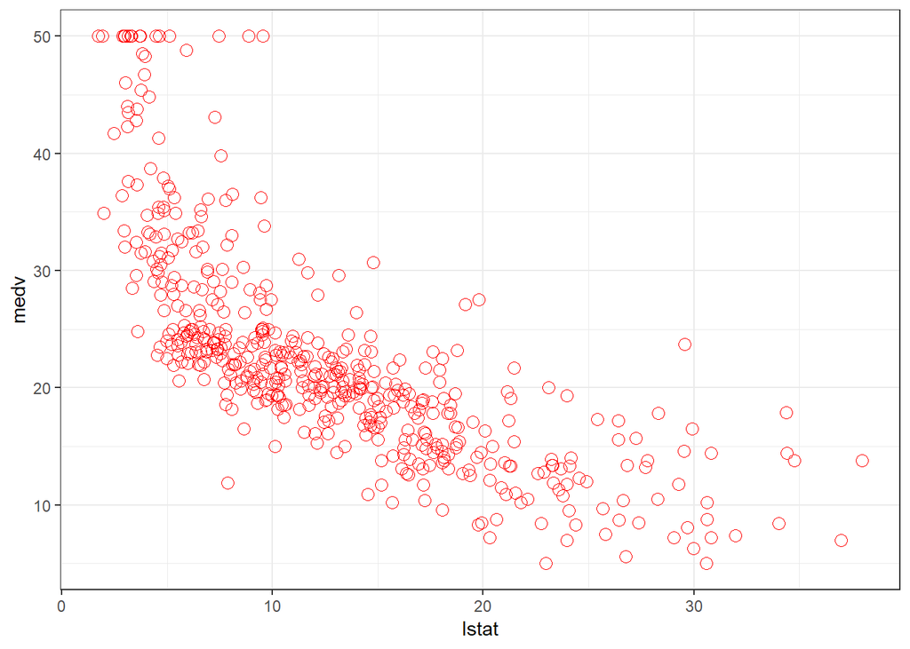

```r
ggplot(Boston, aes(x = lstat, y = medv)) +
  geom_point(color = "red", shape = 21, size = 3)
```